# R Notebook

COMO PRIMERA MEDIDA, ISNTALAMOS LAS LIBRERÍAS QUE NECESITAMOS

```r
install.packages("caret")
```

```
Error in install.packages : Updating loaded packages
```

```r
install.packages("MASS")
```

```
Error in install.packages : Updating loaded packages
```

```r
install.packages("tidyverse")
```

```
Error in install.packages : Updating loaded packages
```

```r
library(lubridate)
library(tseries)
library(tidyverse)
library(foreign)
library(timsac)
library(lmtest)
library(dplyr)
library(caTools)
library(ggplot2)
library(glmnet)
library(car)
library(carData)
library(caret)
library(tidyverse)
library(MASS)

theme_set(theme_classic())
```

Descargamos el dataset a trabajar que consiste en el listado de los jugadores de los equipos de la primera división del fútbol colombiano

| full_name | age | birthday | birthday_GMT | league | season | position | Current.Club | minutes_played_overall | minutes_played_home | minutes_played_away | nationality | appearances_overall | appearances_home | appearances_away | goals_overall | goals_home | goals_away | assists_overall | assists_home | assists_away | penalty_goals | penalty_misses | clean_sheets_overall | clean_sheets_home | clean_sheets_away | conceded_overall | conceded_home | conceded_away | yellow_cards_overall | … |
| --- | --- | --- | --- | --- | --- | --- | --- | --- | --- | --- | --- | --- | --- | --- | --- | --- | --- | --- | --- | --- | --- | --- | --- | --- | --- | --- | --- | --- | --- | --- |
| Adam Ozeri | 24 | 889228800 | 1998/03/07 | Categoria Primera A | 2022 | Midfielder | Patriotas Boyac\xe1 | 37 | 16 | 21 | USA | 2 | 1 | 1 | 0 | 0 | 0 | 0 | 0 | 0 | 0 | 0 | 0 | 0 | 0 | 0 | 0 | 0 | 2 | … |
| Adri\xe1n Arregui | 29 | 713577600 | 1992/08/12 | Categoria Primera A | 2022 | Defender | Independiente Medell\xedn | 1887 | 897 | 990 | Argentina | 22 | 11 | 11 | 3 | 2 | 1 | 2 | 1 | 1 | 0 | 0 | 10 | 8 | 2 | 15 | 2 | 13 | 6 | … |
| Adri\xe1n Estacio | 24 | 893030400 | 1998/04/20 | Categoria Primera A | 2022 | Midfielder | Deportivo Pasto | 536 | 294 | 242 | Colombia | 11 | 5 | 6 | 2 | 2 | 0 | 0 | 0 | 0 | 0 | 0 | 3 | 1 | 2 | 5 | 3 | 2 | 2 | … |
| Agust\xedn Auzmendi | 25 | 854755200 | 1997/02/01 | Categoria Primera A | 2022 | Forward | Jaguares de C\xf3rdoba | 73 | 22 | 51 | Argentina | 4 | 2 | 2 | 0 | 0 | 0 | 0 | 0 | 0 | 0 | 0 | 0 | 0 | 0 | 3 | 1 | 2 | 0 | … |
| Agust\xedn Cano Lotero | 20 | 991958400 | 2001/06/08 | Categoria Primera A | 2022 | Midfielder | Atl\xe9tico Nacional | 30 | 0 | 30 | Colombia | 1 | 0 | 1 | 0 | 0 | 0 | 0 | 0 | 0 | 0 | 0 | 0 | 0 | 0 | 1 | 0 | 1 | 0 | … |
| Agust\xedn Vuletich | 30 | 689126400 | 1991/11/03 | Categoria Primera A | 2022 | Forward | Deportivo Cali | 520 | 280 | 240 | Argentina | 8 | 5 | 3 | 0 | 0 | 0 | 0 | 0 | 0 | 0 | 1 | 1 | 0 | 1 | 4 | 2 | 2 | 2 | … |
| Alain Yuli\xe1n Guerrero Acosta | 20 | 998784000 | 2001/08/26 | Categoria Primera A | 2022 | Defender | Uni\xf3n Magdalena | 66 | 2 | 64 | Colombia | 3 | 1 | 2 | 0 | 0 | 0 | 0 | 0 | 0 | 0 | 0 | 1 | 0 | 1 | 0 | 0 | 0 | 0 | … |
| Aldair Alejandro Quintana Rojas | 27 | 773884800 | 1994/07/11 | Categoria Primera A | 2022 | Goalkeeper | Atl\xe9tico Nacional | 406 | 90 | 316 | Colombia | 5 | 1 | 4 | 0 | 0 | 0 | 0 | 0 | 0 | 0 | 0 | 0 | 0 | 0 | 8 | 1 | 7 | 0 | … |
| Aldair Yesid Guti\xe9rrez Toncel | 23 | 898041600 | 1998/06/17 | Categoria Primera A | 2022 | Defender | Deportivo Cali | 1073 | 536 | 537 | Colombia | 16 | 8 | 8 | 0 | 0 | 0 | 0 | 0 | 0 | 0 | 0 | 4 | 1 | 3 | 13 | 7 | 6 | 4 | … |
| Alejandro Aguilar | 17 | 1090627200 | 2004/07/24 | Categoria Primera A | 2022 | Goalkeeper | Deportes Tolima | 0 | 0 | 0 | Colombia | 0 | 0 | 0 | 0 | 0 | 0 | 0 | 0 | 0 | 0 | 0 | 0 | 0 | 0 | 0 | 0 | 0 | 0 | … |

[output cut: 627 more lines]

```r
data1

summary(data1)
```

```
  full_name              age           birthday         birthday_GMT          league              season       position
 Length:637         Min.   : 0.00   Min.   :0.000e+00   Length:637         Length:637         Min.   :2022   Length:637
 Class :character   1st Qu.:21.00   1st Qu.:7.085e+08   Class :character   Class :character   1st Qu.:2022   Class :character
 Mode  :character   Median :25.00   Median :8.521e+08   Mode  :character   Mode  :character   Median :2022   Mode  :character
                    Mean   :25.11   Mean   :8.172e+08                                         Mean   :2022
                    3rd Qu.:29.00   3rd Qu.:9.573e+08                                         3rd Qu.:2022
                    Max.   :39.00   Max.   :1.128e+09                                         Max.   :2022
 Current.Club       minutes_played_overall minutes_played_home minutes_played_away nationality        appearances_overall
 Length:637         Min.   :   0           Min.   :   0.0      Min.   :   0.0      Length:637         Min.   : 0.00
 Class :character   1st Qu.: 147           1st Qu.:  68.0      1st Qu.:  90.0      Class :character   1st Qu.: 4.00
 Mode  :character   Median : 582           Median : 290.0      Median : 282.0      Mode  :character   Median :11.00
                    Mean   : 666           Mean   : 333.8      Mean   : 332.2                         Mean   :10.27
                    3rd Qu.:1108           3rd Qu.: 549.0      3rd Qu.: 540.0                         3rd Qu.:16.00
                    Max.   :2070           Max.   :1080.0      Max.   :1057.0                         Max.   :24.00
 appearances_home appearances_away goals_overall       goals_home       goals_away     assists_overall   assists_home
 Min.   : 0.000   Min.   : 0.000   Min.   : 0.0000   Min.   :0.0000   Min.   :0.0000   Min.   :0.0000   Min.   :0.0000
 1st Qu.: 2.000   1st Qu.: 2.000   1st Qu.: 0.0000   1st Qu.:0.0000   1st Qu.:0.0000   1st Qu.:0.0000   1st Qu.:0.0000
 Median : 5.000   Median : 5.000   Median : 0.0000   Median :0.0000   Median :0.0000   Median :0.0000   Median :0.0000
 Mean   : 5.127   Mean   : 5.146   Mean   : 0.6986   Mean   :0.4144   Mean   :0.2841   Mean   :0.4411   Mean   :0.2779
 3rd Qu.: 8.000   3rd Qu.: 8.000   3rd Qu.: 1.0000   3rd Qu.:0.0000   3rd Qu.:0.0000   3rd Qu.:1.0000   3rd Qu.:0.0000
 Max.   :12.000   Max.   :12.000   Max.   :12.0000   Max.   :7.0000   Max.   :6.0000   Max.   :9.0000   Max.   :4.0000
  assists_away    penalty_goals   penalty_misses    clean_sheets_overall clean_sheets_home clean_sheets_away conceded_overall
 Min.   :0.0000   Min.   :0.000   Min.   :0.00000   Min.   : 0.00        Min.   :0.000     Min.   :0.000     Min.   : 0.000
 1st Qu.:0.0000   1st Qu.:0.000   1st Qu.:0.00000   1st Qu.: 1.00        1st Qu.:0.000     1st Qu.:0.000     1st Qu.: 2.000
 Median :0.0000   Median :0.000   Median :0.00000   Median : 3.00        Median :2.000     Median :1.000     Median : 6.000
 Mean   :0.1633   Mean   :0.102   Mean   :0.02512   Mean   : 3.25        Mean   :2.053     Mean   :1.196     Mean   : 7.257
 3rd Qu.:0.0000   3rd Qu.:0.000   3rd Qu.:0.00000   3rd Qu.: 5.00        3rd Qu.:3.000     3rd Qu.:2.000     3rd Qu.:12.000
 Max.   :5.0000   Max.   :4.000   Max.   :2.00000   Max.   :14.00        Max.   :9.000     Max.   :7.000     Max.   :27.000
 conceded_home    conceded_away   yellow_cards_overall red_cards_overall goals_involved_per_90_overall assists_per_90_overall
 Min.   : 0.000   Min.   : 0.00   Min.   : 0.000       Min.   :0.0000    Min.   :0.0000                Min.   :0.00000
 1st Qu.: 0.000   1st Qu.: 1.00   1st Qu.: 0.000       1st Qu.:0.0000    1st Qu.:0.0000                1st Qu.:0.00000
 Median : 2.000   Median : 4.00   Median : 1.000       Median :0.0000    Median :0.0000                Median :0.00000
 Mean   : 2.848   Mean   : 4.41   Mean   : 1.931       Mean   :0.1083    Mean   :0.1301                Mean   :0.04947
 3rd Qu.: 5.000   3rd Qu.: 7.00   3rd Qu.: 3.000       3rd Qu.:0.0000    3rd Qu.:0.1900                3rd Qu.:0.06000
 Max.   :11.000   Max.   :19.00   Max.   :11.000       Max.   :3.0000    Max.   :5.0000                Max.   :1.44000
 goals_per_90_overall goals_per_90_home goals_per_90_away min_per_goal_overall conceded_per_90_overall min_per_conceded_overall
 Min.   :0.00000      Min.   :0.00000   Min.   :0.0000    Min.   :   0.0       Min.   : 0.0000         Min.   :  0.00
```

[output cut: 19 more lines]

Revisamos todas las columans que tiene el dataset

```r
names(data1)
```

```
 [1] "full_name"                      "age"                            "birthday"
 [4] "birthday_GMT"                   "league"                         "season"
 [7] "position"                       "Current.Club"                   "minutes_played_overall"
[10] "minutes_played_home"            "minutes_played_away"            "nationality"
[13] "appearances_overall"            "appearances_home"               "appearances_away"
[16] "goals_overall"                  "goals_home"                     "goals_away"
[19] "assists_overall"                "assists_home"                   "assists_away"
[22] "penalty_goals"                  "penalty_misses"                 "clean_sheets_overall"
[25] "clean_sheets_home"              "clean_sheets_away"              "conceded_overall"
[28] "conceded_home"                  "conceded_away"                  "yellow_cards_overall"
[31] "red_cards_overall"              "goals_involved_per_90_overall"  "assists_per_90_overall"
[34] "goals_per_90_overall"           "goals_per_90_home"              "goals_per_90_away"
[37] "min_per_goal_overall"           "conceded_per_90_overall"        "min_per_conceded_overall"
[40] "min_per_match"                  "min_per_card_overall"           "min_per_assist_overall"
[43] "cards_per_90_overall"           "rank_in_league_top_attackers"   "rank_in_league_top_midfielders"
[46] "rank_in_league_top_defenders"   "rank_in_club_top_scorer"
```

Antes de aplicar el modelo de regresión, seleccionamos la cantidad de goles (goals_overall) como variable dependiente y analizaremos si hay colinealidad con las demás variables, pero antes de eso, eliminaremos las columnas que no aportan nada al análisis, como algunas variables categóricas y algunas con campos vacíos

| age | position | minutes_played_overall | minutes_played_home | appearances_overall | appearances_home | goals_overall | goals_home | goals_away | assists_overall | assists_home | penalty_goals | penalty_misses | clean_sheets_overall | clean_sheets_home | conceded_overall | conceded_home | yellow_cards_overall | red_cards_overall | goals_involved_per_90_overall | assists_per_90_overall | goals_per_90_overall | goals_per_90_home | goals_per_90_away | min_per_goal_overall | conceded_per_90_overall | min_per_conceded_overall | min_per_match | min_per_card_overall | cards_per_90_overall |
| --- | --- | --- | --- | --- | --- | --- | --- | --- | --- | --- | --- | --- | --- | --- | --- | --- | --- | --- | --- | --- | --- | --- | --- | --- | --- | --- | --- | --- | --- |
| 24 | Midfielder | 37 | 16 | 2 | 1 | 0 | 0 | 0 | 0 | 0 | 0 | 0 | 0 | 0 | 0 | 0 | 2 | 0 | 0.00 | 0.00 | 0.00 | 0.00 | 0.00 | 0 | 0.00 | 0 | 19 | 19 | 4.86 |
| 29 | Defender | 1887 | 897 | 22 | 11 | 3 | 2 | 1 | 2 | 1 | 0 | 0 | 10 | 8 | 15 | 2 | 6 | 0 | 0.24 | 0.10 | 0.14 | 0.20 | 0.09 | 629 | 0.72 | 126 | 86 | 315 | 0.29 |
| 24 | Midfielder | 536 | 294 | 11 | 5 | 2 | 2 | 0 | 0 | 0 | 0 | 0 | 3 | 1 | 5 | 3 | 2 | 0 | 0.34 | 0.00 | 0.34 | 0.61 | 0.00 | 268 | 0.84 | 107 | 49 | 268 | 0.34 |
| 25 | Forward | 73 | 22 | 4 | 2 | 0 | 0 | 0 | 0 | 0 | 0 | 0 | 0 | 0 | 3 | 1 | 0 | 0 | 0.00 | 0.00 | 0.00 | 0.00 | 0.00 | 0 | 3.70 | 24 | 18 | 0 | 0.00 |
| 20 | Midfielder | 30 | 0 | 1 | 0 | 0 | 0 | 0 | 0 | 0 | 0 | 0 | 0 | 0 | 1 | 0 | 0 | 0 | 0.00 | 0.00 | 0.00 | 0.00 | 0.00 | 0 | 3.00 | 30 | 30 | 0 | 0.00 |
| 30 | Forward | 520 | 280 | 8 | 5 | 0 | 0 | 0 | 0 | 0 | 0 | 1 | 1 | 0 | 4 | 2 | 2 | 0 | 0.00 | 0.00 | 0.00 | 0.00 | 0.00 | 0 | 0.69 | 130 | 65 | 260 | 0.35 |
| 20 | Defender | 66 | 2 | 3 | 1 | 0 | 0 | 0 | 0 | 0 | 0 | 0 | 1 | 0 | 0 | 0 | 0 | 0 | 0.00 | 0.00 | 0.00 | 0.00 | 0.00 | 0 | 0.00 | 0 | 22 | 0 | 0.00 |
| 27 | Goalkeeper | 406 | 90 | 5 | 1 | 0 | 0 | 0 | 0 | 0 | 0 | 0 | 0 | 0 | 8 | 1 | 0 | 0 | 0.00 | 0.00 | 0.00 | 0.00 | 0.00 | 0 | 1.77 | 51 | 81 | 0 | 0.00 |
| 23 | Defender | 1073 | 536 | 16 | 8 | 0 | 0 | 0 | 0 | 0 | 0 | 0 | 4 | 1 | 13 | 7 | 4 | 1 | 0.00 | 0.00 | 0.00 | 0.00 | 0.00 | 0 | 1.09 | 83 | 67 | 215 | 0.42 |
| 17 | Goalkeeper | 0 | 0 | 0 | 0 | 0 | 0 | 0 | 0 | 0 | 0 | 0 | 0 | 0 | 0 | 0 | 0 | 0 | 0.00 | 0.00 | 0.00 | 0.00 | 0.00 | 0 | 0.00 | 0 | 0 | 0 | 0.00 |

[output cut: 627 more lines]

De las varaibles resultantes, se hará una gráfica que muestre la correlación entre las variables más relevantes para el modelo de regresión que se va a trabajar

```r
l<-c('age','minutes_played_overall','appearances_overall','goals_overall','assists_overall','penalty_goals','clean_sheets_overall','yellow_cards_overall','red_cards_overall')
```

```r
sample_data <- data2[l]
pairs( sample_data )
```

[output not shown]

Para poder observar si hay colinealidad en el modelo de regersión, separamos los datos en dos grupos train y test para poder hacer cross validation.

```r
#Dividimos los datos en training(80%) y testing(20%)
set.seed(123)

training.muestras <- data2$goals_overall%>%
  createDataPartition(p=.8,list=FALSE)

train.datos <- data2[training.muestras, ]

test.datos <- data2[-training.muestras, ]
```

```r
#Construimos el modelo de Regresión

modelo1 <- lm(goals_overall ~., data = train.datos)

coef(modelo1)
```

[output not shown]

```r
#Se hacen predicciones
predicciones <-modelo1 %>% predict(test.datos)

predicciones
```

[output not shown]

```r
#Revisamos el desempeño del modelo 1

data.frame(RMSE=RMSE(predicciones, test.datos$goals_overall),R2=R2(predicciones,test.datos$goals_overall))
```

[output not shown]

```r
#Detectando Multicolinealidad


#Se revisa el factor de  inflación de varianza

car::vif(modelo1)
```

[output not shown]

```r
#Se revisan los valores mas altos como minutes_played_overall con valor mayor que 10
# valores por encima de 5 son un problema! Así que se recomienda eliminar la variable

modelo2 <- lm(goals_overall ~. -minutes_played_overall-minutes_played_home-appearances_overall-appearances_home  -clean_sheets_overall-clean_sheets_home-conceded_overall-conceded_home-goals_involved_per_90_overall-assists_per_90_overall-goals_per_90_overall,  data = train.datos)
coef(modelo2)
```

[output not shown]

```r
#Se hacen predicciones nuevamente

predicciones2 <-modelo2 %>% predict(test.datos)
predicciones2
```

[output not shown]

```r
data.frame(RMSE=RMSE(predicciones2, test.datos$goals_overall),R2=R2(predicciones2,test.datos$goals_overall))
```

[output not shown]

```r
car::vif(modelo2)
```

[output not shown]

Ahora se implementará el modelo de regresión RIDGE

```r
#Librerías necesarias
install.packages("glmnet")
install.packages("pacman")
library(caret)
library(glmnet)
library(pacman)
pacman::p_load(pacman,dplyr, ggplot2, rio, gridExtra, scales, ggcorrplot, e1071)
```

```r
summary(train.datos)
```

```
      age          position         minutes_played_overall minutes_played_home
 Min.   : 0.00   Length:510         Min.   :   0.0         Min.   :   0.00
 1st Qu.:21.00   Class :character   1st Qu.: 145.0         1st Qu.:  70.75
 Median :25.00   Mode  :character   Median : 562.0         Median : 277.50
 Mean   :25.06                      Mean   : 648.8         Mean   : 325.68
 3rd Qu.:29.00                      3rd Qu.:1073.0         3rd Qu.: 540.00
 Max.   :39.00                      Max.   :2070.0         Max.   :1080.00
 appearances_overall appearances_home goals_overall       goals_home       goals_away
 Min.   : 0.00       Min.   : 0.000   Min.   : 0.0000   Min.   :0.0000   Min.   :0.0000
 1st Qu.: 4.00       1st Qu.: 2.000   1st Qu.: 0.0000   1st Qu.:0.0000   1st Qu.:0.0000
 Median :10.50       Median : 5.000   Median : 0.0000   Median :0.0000   Median :0.0000
 Mean   :10.06       Mean   : 5.037   Mean   : 0.6686   Mean   :0.3922   Mean   :0.2765
 3rd Qu.:16.00       3rd Qu.: 8.000   3rd Qu.: 1.0000   3rd Qu.:0.0000   3rd Qu.:0.0000
 Max.   :24.00       Max.   :12.000   Max.   :12.0000   Max.   :7.0000   Max.   :6.0000
 assists_overall   assists_home    penalty_goals    penalty_misses    clean_sheets_overall
 Min.   :0.0000   Min.   :0.0000   Min.   :0.0000   Min.   :0.00000   Min.   : 0.0
 1st Qu.:0.0000   1st Qu.:0.0000   1st Qu.:0.0000   1st Qu.:0.00000   1st Qu.: 1.0
 Median :0.0000   Median :0.0000   Median :0.0000   Median :0.00000   Median : 2.5
 Mean   :0.4392   Mean   :0.2569   Mean   :0.0902   Mean   :0.01765   Mean   : 3.2
 3rd Qu.:1.0000   3rd Qu.:0.0000   3rd Qu.:0.0000   3rd Qu.:0.00000   3rd Qu.: 5.0
 Max.   :9.0000   Max.   :4.0000   Max.   :4.0000   Max.   :1.00000   Max.   :13.0
 clean_sheets_home conceded_overall conceded_home    yellow_cards_overall red_cards_overall
 Min.   :0.000     Min.   : 0.000   Min.   : 0.000   Min.   : 0.000       Min.   :0.0000
 1st Qu.:0.000     1st Qu.: 2.000   1st Qu.: 0.000   1st Qu.: 0.000       1st Qu.:0.0000
 Median :2.000     Median : 6.000   Median : 2.000   Median : 1.000       Median :0.0000
 Mean   :2.027     Mean   : 7.094   Mean   : 2.765   Mean   : 1.888       Mean   :0.1059
 3rd Qu.:3.000     3rd Qu.:11.000   3rd Qu.: 5.000   3rd Qu.: 3.000       3rd Qu.:0.0000
 Max.   :9.000     Max.   :27.000   Max.   :10.000   Max.   :11.000       Max.   :3.0000
 goals_involved_per_90_overall assists_per_90_overall goals_per_90_overall goals_per_90_home
 Min.   :0.0000                Min.   :0.00000        Min.   :0.00000      Min.   :0.00000
 1st Qu.:0.0000                1st Qu.:0.00000        1st Qu.:0.00000      1st Qu.:0.00000
 Median :0.0000                Median :0.00000        Median :0.00000      Median :0.00000
 Mean   :0.1349                Mean   :0.05163        Mean   :0.08324      Mean   :0.08263
 3rd Qu.:0.2000                3rd Qu.:0.06000        3rd Qu.:0.08000      3rd Qu.:0.00000
 Max.   :5.0000                Max.   :1.44000        Max.   :5.00000      Max.   :1.57000
 goals_per_90_away min_per_goal_overall conceded_per_90_overall min_per_conceded_overall
 Min.   :0.00000   Min.   :   0.0       Min.   : 0.0000         Min.   :  0.00
 1st Qu.:0.00000   1st Qu.:   0.0       1st Qu.: 0.5725         1st Qu.: 53.00
 Median :0.00000   Median :   0.0       Median : 0.9250         Median : 79.00
 Mean   :0.06273   Mean   : 175.9       Mean   : 0.9888         Mean   : 83.67
 3rd Qu.:0.00000   3rd Qu.: 209.5       3rd Qu.: 1.2700         3rd Qu.:112.00
 Max.   :1.53000   Max.   :2047.0       Max.   :12.8600         Max.   :593.00
 min_per_match   min_per_card_overall cards_per_90_overall
 Min.   : 0.00   Min.   :   0.0       Min.   : 0.0000
 1st Qu.:34.00   1st Qu.:   0.0       1st Qu.: 0.0000
 Median :59.00   Median : 173.5       Median : 0.2000
 Mean   :54.01   Mean   : 225.7       Mean   : 0.4136
 3rd Qu.:77.00   3rd Qu.: 325.5       3rd Qu.: 0.4000
 Max.   :90.00   Max.   :1800.0       Max.   :45.0000
```

```r
summary(test.datos)
```

```
      age          position         minutes_played_overall minutes_played_home
 Min.   : 0.00   Length:127         Min.   :   0.0         Min.   :   0.0
 1st Qu.:22.00   Class :character   1st Qu.: 167.5         1st Qu.:  54.0
 Median :25.00   Mode  :character   Median : 663.0         Median : 348.0
 Mean   :25.31                      Mean   : 735.0         Mean   : 366.2
 3rd Qu.:29.00                      3rd Qu.:1192.0         3rd Qu.: 624.0
 Max.   :37.00                      Max.   :2070.0         Max.   :1080.0
 appearances_overall appearances_home goals_overall       goals_home       goals_away
 Min.   : 0.00       Min.   : 0.000   Min.   : 0.0000   Min.   :0.0000   Min.   :0.000
 1st Qu.: 4.50       1st Qu.: 2.000   1st Qu.: 0.0000   1st Qu.:0.0000   1st Qu.:0.000
 Median :13.00       Median : 7.000   Median : 0.0000   Median :0.0000   Median :0.000
 Mean   :11.12       Mean   : 5.488   Mean   : 0.8189   Mean   :0.5039   Mean   :0.315
 3rd Qu.:17.00       3rd Qu.: 8.000   3rd Qu.: 1.0000   3rd Qu.:0.5000   3rd Qu.:0.000
 Max.   :23.00       Max.   :12.000   Max.   :10.0000   Max.   :7.0000   Max.   :5.000
 assists_overall   assists_home    penalty_goals    penalty_misses    clean_sheets_overall
 Min.   :0.0000   Min.   :0.0000   Min.   :0.0000   Min.   :0.00000   Min.   : 0.000
 1st Qu.:0.0000   1st Qu.:0.0000   1st Qu.:0.0000   1st Qu.:0.00000   1st Qu.: 1.000
 Median :0.0000   Median :0.0000   Median :0.0000   Median :0.00000   Median : 3.000
 Mean   :0.4488   Mean   :0.3622   Mean   :0.1496   Mean   :0.05512   Mean   : 3.449
 3rd Qu.:0.5000   3rd Qu.:0.0000   3rd Qu.:0.0000   3rd Qu.:0.00000   3rd Qu.: 5.000
 Max.   :5.0000   Max.   :4.0000   Max.   :4.0000   Max.   :2.00000   Max.   :14.000
 clean_sheets_home conceded_overall conceded_home    yellow_cards_overall red_cards_overall
 Min.   :0.000     Min.   : 0.000   Min.   : 0.000   Min.   : 0.000       Min.   :0.0000
 1st Qu.:1.000     1st Qu.: 2.000   1st Qu.: 0.000   1st Qu.: 0.000       1st Qu.:0.0000
 Median :2.000     Median : 6.000   Median : 2.000   Median : 1.000       Median :0.0000
 Mean   :2.157     Mean   : 7.913   Mean   : 3.181   Mean   : 2.102       Mean   :0.1181
 3rd Qu.:3.000     3rd Qu.:14.000   3rd Qu.: 6.000   3rd Qu.: 3.000       3rd Qu.:0.0000
 Max.   :9.000     Max.   :24.000   Max.   :11.000   Max.   :10.000       Max.   :1.0000
 goals_involved_per_90_overall assists_per_90_overall goals_per_90_overall goals_per_90_home
 Min.   :0.0000                Min.   :0.00000        Min.   :0.00000      Min.   :0.00000
 1st Qu.:0.0000                1st Qu.:0.00000        1st Qu.:0.00000      1st Qu.:0.00000
 Median :0.0000                Median :0.00000        Median :0.00000      Median :0.00000
 Mean   :0.1109                Mean   :0.04079        Mean   :0.07024      Mean   :0.08346
 3rd Qu.:0.1500                3rd Qu.:0.03500        3rd Qu.:0.07500      3rd Qu.:0.04500
 Max.   :0.7600                Max.   :0.55000        Max.   :0.67000      Max.   :0.97000
 goals_per_90_away min_per_goal_overall conceded_per_90_overall min_per_conceded_overall
 Min.   :0.00000   Min.   :   0.0       Min.   :0.0000          Min.   :  0.00
 1st Qu.:0.00000   1st Qu.:   0.0       1st Qu.:0.5450          1st Qu.: 59.50
 Median :0.00000   Median :   0.0       Median :0.9500          Median : 84.00
 Mean   :0.05559   Mean   : 222.6       Mean   :0.9929          Mean   : 87.55
 3rd Qu.:0.00000   3rd Qu.: 231.0       3rd Qu.:1.2150          3rd Qu.:112.50
 Max.   :0.84000   Max.   :1947.0       Max.   :9.0000          Max.   :285.00
 min_per_match   min_per_card_overall cards_per_90_overall
 Min.   : 0.00   Min.   :   0.0       Min.   :0.0000
 1st Qu.:33.50   1st Qu.:   0.0       1st Qu.:0.0000
 Median :58.00   Median : 189.0       Median :0.1700
 Mean   :55.56   Mean   : 275.6       Mean   :0.2905
 3rd Qu.:82.00   3rd Qu.: 410.5       3rd Qu.:0.3750
 Max.   :90.00   Max.   :1710.0       Max.   :4.8600
```

```r
#Para conocer las dimensiones de mis datos
dim(train.datos)
```

```
[1] 510  30
```

```r
dim(test.datos)
```

```
[1] 127  30
```

```r
head(x)
```

```
  (Intercept) age positionForward positionGoalkeeper positionMidfielder
2           1  29               0                  0                  0
3           1  24               0                  0                  1
5           1  20               0                  0                  1
6           1  30               1                  0                  0
7           1  20               0                  0                  0
8           1  27               0                  1                  0
  minutes_played_overall minutes_played_home appearances_overall appearances_home
2                   1887                 897                  22               11
3                    536                 294                  11                5
5                     30                   0                   1                0
6                    520                 280                   8                5
7                     66                   2                   3                1
8                    406                  90                   5                1
  goals_home goals_away assists_overall assists_home penalty_goals penalty_misses
```

[output cut: 41 more lines]

```r
head(x)
```

```
  age positionForward positionGoalkeeper positionMidfielder minutes_played_overall
2  29               0                  0                  0                   1887
3  24               0                  0                  1                    536
5  20               0                  0                  1                     30
6  30               1                  0                  0                    520
7  20               0                  0                  0                     66
8  27               0                  1                  0                    406
  minutes_played_home appearances_overall appearances_home goals_home goals_away
2                 897                  22               11          2          1
3                 294                  11                5          2          0
5                   0                   1                0          0          0
6                 280                   8                5          0          0
7                   2                   3                1          0          0
8                  90                   5                1          0          0
  assists_overall assists_home penalty_goals penalty_misses clean_sheets_overall
```

[output cut: 34 more lines]

```r
y
```

```
  [1]  3  2  0  0  0  0  0  0  1  0  2  0  0  0  1  0  3  0  0  1  0  4  0  0  0  2  0  6  4
 [30]  0  0  0  0  1  0  0  0  0  1  0  0  0  0  2  3  0  0  0  0  5  0  1  0  0  3  0  1  0
 [59]  0  1  0  0  0  0  0  1  0  0  0  0  0  0  0  6  0  0  1  3  0  0  0  0  0  4  0  1  0
 [88]  0  0  0  0  1  0  0  3  2  0  2  0  1  4  1  0  2  0  0  0  0  0  1  6  0  0  1  1  0
[117]  0 12  0  1  0  1  0  0  0  0  0  0  6  5  0  1  6  0  0  0  8  0  0  2  3  0  0  0  0
[146]  0  2  2  0  0  1  0  0  1  0  0  0  0  0  1  0  0  0  0  2  1  0  0  0  1  0  1  0  0
[175]  1  1  0  1  0  0  1  0  3  0  0  0  2  0  0  0  0  0  0  0  0  3  0  1  0  0  2  0  0
[204]  1  1  0  0  0  0  0  1  0  1  0  0  0  3  0  0  0  0  0  0  0  0  0  0  0  3  0  0  3
[233]  0  0  1  0  0  7  0  0  0  0  0  0  3  0  1  2  0  0  6  0  0  1  0  0  0  1  0  2  0
[262]  0  1  3  0  0  0  0  0  0  0  0  0  0  1  0  0  0  0  0  0  0  0  0  0  0  0  0  0  0
[291]  0  0  0  0  0  0  0  0  1  0  0  0  0  3  0  2  0  0  0  2  2  0  0  0  2  0  0  0  0
[320]  0  0  0  0  0  3  0  1  0  0  1  0  1  2  1  0  0  0  0  0  0  4  0  0  3  0  0  0  0
[349]  1  1  0  0  0  1  1  0  0  0  0  1  0  0  1  0  0  0  2  0  1  0  3  1  0  0  0  0  0
[378]  0  0  0  1  0  0  2  1  0  0  0  0 10  0  0  0 11  6  0  0  0  0  0  1  4  0  1  0  0
[407]  0  0  0  3  1  2  0  0  0  0  0  1  2  0  5  0  0  0  0  2  0  0  0  0  0  0  0  0  0
[436]  0  0  0  0  5  3  3  0  0  1  0  0  0  0  1  0  0  0  1  0  0  0  0  0  0  0  0  1  0
[465]  0  0  0  0  2  0  1  2  0  0  2  0  1  0  0  1  1  2  0  0  1  0  1  3  0  2  0  1  0
[494]  0  1  1  3  0  0  0  0  0  0  3  0  0  2  0  0  0
```

```r
dim(coef(ridge.model))
```

```
[1]  32 100
```

```r
#construye 100 modelos por defecto
coef(ridge.model)
```

```
32 x 100 sparse Matrix of class "dgCMatrix"
```

```
  [[ suppressing 39 column names ‘s0’, ‘s1’, ‘s2’ ... ]]
  [[ suppressing 39 column names ‘s0’, ‘s1’, ‘s2’ ... ]]
```

```
(Intercept)             6.686275e-01  6.544810e-01  6.531204e-01  6.516308e-01
age                     6.026698e-38  7.133766e-05  7.819674e-05  8.570563e-05
positionForward         9.930400e-37  1.184091e-03  1.298867e-03  1.424698e-03
positionGoalkeeper     -6.965942e-37 -8.271800e-04 -9.069945e-04 -9.944248e-04
positionMidfielder     -9.368087e-38 -1.114346e-04 -1.222075e-04 -1.340121e-04
minutes_played_overall  1.065303e-39  1.258757e-06  1.379547e-06  1.511734e-06
minutes_played_home     2.131510e-39  2.519770e-06  2.761699e-06  3.026475e-06
appearances_overall     9.833340e-38  1.162815e-04  1.274500e-04  1.396738e-04
appearances_home        1.901041e-37  2.248445e-04  2.464448e-04  2.700870e-04
goals_home              1.411286e-36  1.681783e-03  1.844696e-03  2.023281e-03
goals_away              1.699695e-36  2.024979e-03  2.221086e-03  2.436045e-03
assists_overall         5.347989e-37  6.336941e-04  6.946962e-04  7.614892e-04
assists_home            6.711808e-37  7.948952e-04  8.713729e-04  9.551015e-04

(Intercept)             6.500004e-01  6.482166e-01  6.462652e-01  6.441314e-01
age                     9.392343e-05  1.029146e-04  1.127490e-04  1.235022e-04
positionForward         1.562634e-03  1.713821e-03  1.879512e-03  2.061073e-03
positionGoalkeeper     -1.090177e-03 -1.195023e-03 -1.309799e-03 -1.435416e-03
positionMidfielder     -1.469452e-04 -1.611123e-04 -1.766284e-04 -1.936183e-04
minutes_played_overall  1.656342e-06  1.814489e-06  1.987385e-06  2.176335e-06
minutes_played_home     3.316164e-06  3.633013e-06  3.979457e-06  4.358123e-06
appearances_overall     1.530487e-04  1.676787e-04  1.836765e-04  2.011639e-04
appearances_home        2.959565e-04  3.242551e-04  3.552010e-04  3.890301e-04
goals_home              2.219020e-03  2.433536e-03  2.668596e-03  2.926130e-03
goals_away              2.671641e-03  2.929820e-03  3.212707e-03  3.522617e-03
assists_overall         8.346051e-04  9.146224e-04  1.002169e-03  1.097924e-03
assists_home            1.046746e-03  1.147028e-03  1.256731e-03  1.376702e-03

(Intercept)             6.417988e-01  6.392499e-01  6.364658e-01  6.334262e-01
age                     1.352558e-04  1.480979e-04  1.621234e-04  1.774340e-04
positionForward         2.259994e-03  2.477898e-03  2.716554e-03  2.977885e-03
positionGoalkeeper     -1.572861e-03 -1.723204e-03 -1.887602e-03 -2.067306e-03
positionMidfielder     -2.122181e-04 -2.325751e-04 -2.548497e-04 -2.792151e-04
minutes_played_overall  2.382743e-06  2.608124e-06  2.854099e-06  3.122408e-06
minutes_played_home     4.771845e-06  5.223672e-06  5.716882e-06  6.254987e-06
appearances_overall     2.202721e-04  2.411425e-04  2.639272e-04  2.887892e-04
appearances_home        4.259971e-04  4.663762e-04  5.104623e-04  5.585718e-04
goals_home              3.208240e-03  3.517216e-03  3.855551e-03  4.225956e-03
goals_away              3.862075e-03  4.233827e-03  4.640864e-03  5.086434e-03
assists_overall         1.202624e-03  1.317063e-03  1.442097e-03  1.578650e-03
```

[output cut: 88 more lines]

```
positionForward         2.712441e-02  2.941623e-02  3.186897e-02 ......
positionGoalkeeper     -1.735108e-02 -1.867406e-02 -2.006669e-02 ......
positionMidfielder     -2.406128e-03 -2.593867e-03 -2.791715e-03 ......
minutes_played_overall  2.377247e-05  2.535757e-05  2.699119e-05 ......
minutes_played_home     4.813610e-05  5.140366e-05  5.478261e-05 ......
appearances_overall     2.232905e-03  2.385109e-03  2.542502e-03 ......
appearances_home        4.336845e-03  4.634460e-03  4.942610e-03 ......
goals_home              3.838212e-02  4.164819e-02  4.515489e-02 ......
goals_away              4.592210e-02  4.979676e-02  5.395021e-02 ......
assists_overall         1.271470e-02  1.363369e-02  1.459323e-02 ......
assists_home            1.575998e-02  1.687967e-02  1.804510e-02 ......

 ..............................
 ........suppressing 61 columns and 7 rows in show(); maybe adjust 'options(max.print= *, width = *)'
 ..............................
```

```
  [[ suppressing 39 column names ‘s0’, ‘s1’, ‘s2’ ... ]]
```

```
red_cards_overall              3.749873e-37  4.421821e-04  4.845209e-04  5.308319e-04
goals_involved_per_90_overall  2.297679e-36  2.732074e-03  2.996089e-03  3.285369e-03
assists_per_90_overall         2.160314e-36  2.557070e-03  2.802934e-03  3.072073e-03
goals_per_90_overall           2.520685e-36  2.999794e-03  3.289953e-03  3.607933e-03
goals_per_90_home              4.589537e-36  5.468104e-03  5.997682e-03  6.578172e-03
goals_per_90_away              4.859343e-36  5.787798e-03  6.348149e-03  6.962333e-03
min_per_goal_overall           1.245453e-39  1.475992e-06  1.618106e-06  1.773714e-06
conceded_per_90_overall       -3.552091e-38 -4.258315e-05 -4.673518e-05 -5.129205e-05
min_per_conceded_overall       4.373518e-39  5.156300e-06  5.649912e-06  6.189811e-06
min_per_match                  1.008887e-38  1.186593e-05  1.299881e-05  1.423730e-05
min_per_card_overall           1.557953e-39  1.843991e-06  2.021288e-06  2.215369e-06
cards_per_90_overall          -2.340638e-38 -2.765692e-05 -3.031109e-05 -3.321551e-05

red_cards_overall              5.814713e-04  6.368239e-04  6.973047e-04  7.633605e-04
goals_involved_per_90_overall  3.602281e-03  3.949402e-03  4.329540e-03  4.745748e-03
assists_per_90_overall         3.366617e-03  3.688876e-03  4.041350e-03  4.426747e-03
goals_per_90_overall           3.956352e-03  4.338063e-03  4.756177e-03  5.214080e-03
goals_per_90_home              7.214395e-03  7.911611e-03  8.675556e-03  9.512488e-03
goals_per_90_away              7.635438e-03  8.373015e-03  9.181118e-03  1.006635e-02
min_per_goal_overall           1.944059e-06  2.130491e-06  2.334476e-06  2.557600e-06
conceded_per_90_overall       -5.629324e-05 -6.178205e-05 -6.780602e-05 -7.441732e-05
min_per_conceded_overall       6.780144e-06  7.425389e-06  8.130371e-06  8.900288e-06
min_per_match                  1.559075e-05  1.706920e-05  1.868346e-05  2.044513e-05
min_per_card_overall           2.427770e-06  2.660158e-06  2.914337e-06  3.192260e-06
cards_per_90_overall          -3.639286e-05 -3.986772e-05 -4.366666e-05 -4.781835e-05

red_cards_overall              8.354712e-04  9.141514e-04  9.999510e-04  1.093457e-03
goals_involved_per_90_overall  5.201345e-03  5.699934e-03  6.245422e-03  6.842042e-03
assists_per_90_overall         4.847988e-03  5.308225e-03  5.810850e-03  6.359506e-03
goals_per_90_overall           5.715455e-03  6.264306e-03  6.864982e-03  7.522200e-03
goals_per_90_home              1.042922e-02  1.143318e-02  1.253244e-02  1.373578e-02
goals_per_90_away              1.103588e-02  1.209755e-02  1.325986e-02  1.453205e-02
min_per_goal_overall           2.801582e-06  3.068276e-06  3.359687e-06  3.677972e-06
conceded_per_90_overall       -8.167319e-05 -8.963644e-05 -9.837600e-05 -1.079675e-04
min_per_conceded_overall       9.740718e-06  1.065764e-05  1.165744e-05  1.274692e-05
min_per_match                  2.236661e-05  2.446114e-05  2.674280e-05  2.922649e-05
min_per_card_overall           3.496036e-06  3.827942e-06  4.190426e-06  4.586123e-06
cards_per_90_overall          -5.235369e-05 -5.730594e-05 -6.271078e-05 -6.860640e-05

red_cards_overall              1.195291e-03  1.306114e-03  1.426624e-03  1.557546e-03
```

[output cut: 74 more lines]

```
min_per_card_overall           2.712636e-05  2.922868e-05  3.144814e-05  3.378404e-05
cards_per_90_overall          -3.955861e-04 -4.250342e-04 -4.558902e-04 -4.880928e-04

red_cards_overall              7.923388e-03  8.405526e-03  8.893207e-03 ......
goals_involved_per_90_overall  5.901542e-02  6.368155e-02  6.862323e-02 ......
assists_per_90_overall         4.966834e-02  5.305457e-02  5.654461e-02 ......
goals_per_90_overall           6.601525e-02  7.135292e-02  7.702678e-02 ......
goals_per_90_home              1.239105e-01  1.343346e-01  1.454991e-01 ......
goals_per_90_away              1.301519e-01  1.409912e-01  1.525785e-01 ......
min_per_goal_overall           2.983488e-05  3.202522e-05  3.432089e-05 ......
conceded_per_90_overall       -1.096146e-03 -1.201082e-03 -1.315695e-03 ......
min_per_conceded_overall       9.143514e-05  9.683228e-05  1.022424e-04 ......
min_per_match                  1.993794e-04  2.101364e-04  2.207406e-04 ......
min_per_card_overall           3.623437e-05  3.879580e-05  4.146349e-05 ......
cards_per_90_overall          -5.215569e-04 -5.561716e-04 -5.917989e-04 ......
```

```r
ridge.model$lambda
```

```
  [1] 1337.7899928 1218.9444169 1110.6567545 1011.9890695  922.0867497  840.1711043
  [7]  765.5326190  697.5248110  635.5586292  579.0973523  527.6519396  480.7767955
 [13]  438.0659101  399.1493420  363.6900146  331.3807960  301.9418394  275.1181586
 [19]  250.6774197  228.4079286  208.1167977  189.6282750  172.7822217  157.4327253
 [25]  143.4468359  130.7034144  119.0920833  108.5122708   98.8723398   90.0887936
 [31]   82.0855535   74.7932991   68.1488686   62.0947109   56.5783879   51.5521199
 [37]   46.9723716   42.7994756   38.9972882   35.5328766   32.3762337   29.5000184
 [43]   26.8793180   24.4914335   22.3156821   20.3332184   18.5268713   16.8809951
 [49]   15.3813340   14.0148987   12.7698537   11.6354151   10.6017569    9.6599260
 [55]    8.8017648    8.0198403    7.3073798    6.6582123    6.0667151    5.5277648
 [61]    5.0366934    4.5892475    4.1815514    3.8100739    3.4715974    3.1631903
 [67]    2.8821812    2.6261361    2.3928374    2.1802644    1.9865757    1.8100938
 [73]    1.6492900    1.5027716    1.3692696    1.2476274    1.1367916    1.0358022
 [79]    0.9437844    0.8599412    0.7835464    0.7139383    0.6505140    0.5927241
 [85]    0.5400681    0.4920900    0.4483740    0.4085417    0.3722480    0.3391785
 [91]    0.3090468    0.2815920    0.2565761    0.2337826    0.2130140    0.1940904
 [97]    0.1768480    0.1611373    0.1468223    0.1337790
```

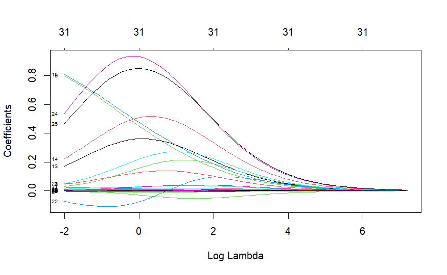

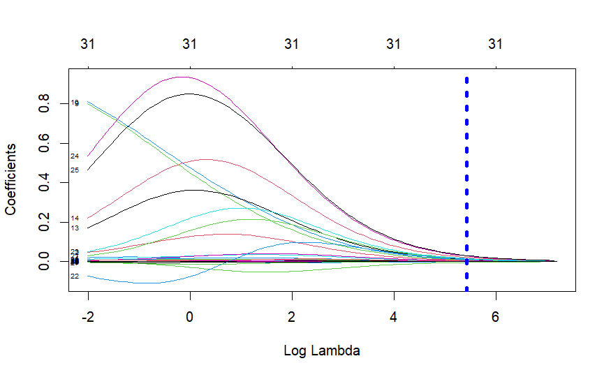

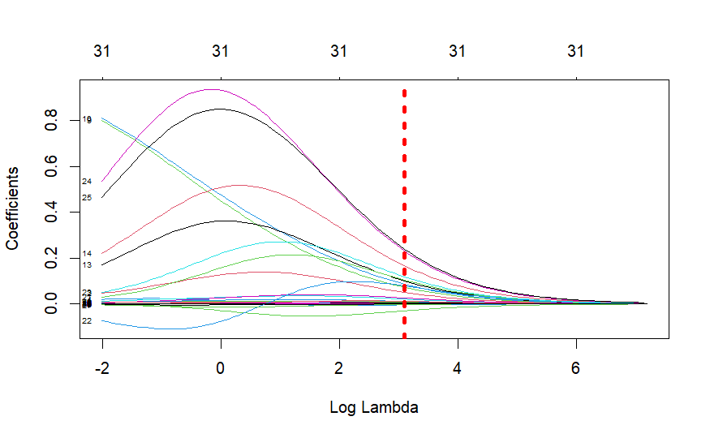

```r
pred
```

```
           s1
1   0.2861590
4   0.3607096
18  0.3346236
20  0.4906633
21  0.6803038
25  0.9204951
35  0.5146744
40  0.5918781
43  2.1494876
54  0.2451474
60  0.3542864
66  1.3364552
70  0.3074487
72  1.0100686
```

[output cut: 113 more lines]

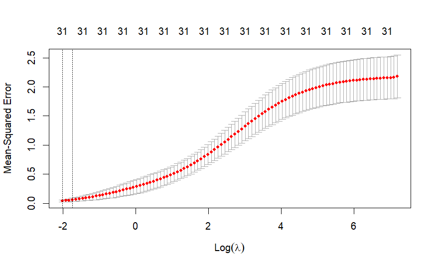

```r
log(mejor.lambda)
```

```
[1] -2.011566
```

```r
#hacer prediccion con el mejor lambda
coef(ridge.model)[,which(ridge.model$lambda==mejor.lambda)]
```

```
                  (Intercept)                           age               positionForward
                -2.826285e-02                 -6.971972e-04                  4.571784e-02
           positionGoalkeeper            positionMidfielder        minutes_played_overall
                -2.785250e-03                  2.006507e-02                  3.567046e-05
          minutes_played_home           appearances_overall              appearances_home
                 1.277726e-04                 -1.474561e-03                 -4.336702e-04
                   goals_home                    goals_away               assists_overall
                 8.003212e-01                  8.096496e-01                  1.214358e-02
                 assists_home                 penalty_goals                penalty_misses
                 4.352718e-03                  1.706975e-01                  2.200521e-01
         clean_sheets_overall             clean_sheets_home              conceded_overall
                 6.169437e-03                  5.825470e-03                 -2.061652e-04
                conceded_home          yellow_cards_overall             red_cards_overall
                -8.720942e-05                 -2.927927e-03                  7.281224e-03
goals_involved_per_90_overall        assists_per_90_overall          goals_per_90_overall
                 2.846747e-02                 -7.414825e-02                  4.973895e-02
            goals_per_90_home             goals_per_90_away          min_per_goal_overall
                 5.353328e-01                  4.649615e-01                  2.420381e-05
      conceded_per_90_overall      min_per_conceded_overall                 min_per_match
                -4.321692e-03                 -2.911438e-04                  1.455120e-05
         min_per_card_overall          cards_per_90_overall
                 2.323486e-05                 -1.499813e-05
```

```r
pred
```

```
               s1
1   -3.015995e-02
4   -2.474708e-02
18  -1.450747e-02
20  -4.904639e-03
21   5.411571e-02
25   2.148474e-01
35  -3.858447e-02
40   1.283666e-02
43   6.244116e+00
54  -4.153317e-02
60  -6.887701e-02
66   3.000821e+00
70  -5.677044e-02
72   1.035988e+00
```

[output cut: 113 more lines]

| RMSE | s1 |
| --- | --- |
| 0.1454653 | 0.9951767 |

Ahora se implementará el modelo de regresión LASSO

```r
print(x)
```

```
    age positionForward positionGoalkeeper positionMidfielder minutes_played_overall
2    29               0                  0                  0                   1887
3    24               0                  0                  1                    536
5    20               0                  0                  1                     30
6    30               1                  0                  0                    520
7    20               0                  0                  0                     66
8    27               0                  1                  0                    406
9    23               0                  0                  0                   1073
10   17               0                  1                  0                      0
11   24               0                  0                  1                   1006
12   30               0                  0                  1                    348
13   30               1                  0                  0                    646
14   21               0                  0                  0                    104
15   27               0                  0                  0                    228
16   21               0                  0                  1                     61
```

[output cut: 217 more lines]

```r
print(y)
```

```
  [1]  3  2  0  0  0  0  0  0  1  0  2  0  0  0  1  0  3  0  0  1  0  4  0  0  0  2  0  6  4
 [30]  0  0  0  0  1  0  0  0  0  1  0  0  0  0  2  3  0  0  0  0  5  0  1  0  0  3  0  1  0
 [59]  0  1  0  0  0  0  0  1  0  0  0  0  0  0  0  6  0  0  1  3  0  0  0  0  0  4  0  1  0
 [88]  0  0  0  0  1  0  0  3  2  0  2  0  1  4  1  0  2  0  0  0  0  0  1  6  0  0  1  1  0
[117]  0 12  0  1  0  1  0  0  0  0  0  0  6  5  0  1  6  0  0  0  8  0  0  2  3  0  0  0  0
[146]  0  2  2  0  0  1  0  0  1  0  0  0  0  0  1  0  0  0  0  2  1  0  0  0  1  0  1  0  0
[175]  1  1  0  1  0  0  1  0  3  0  0  0  2  0  0  0  0  0  0  0  0  3  0  1  0  0  2  0  0
[204]  1  1  0  0  0  0  0  1  0  1  0  0  0  3  0  0  0  0  0  0  0  0  0  0  0  3  0  0  3
[233]  0  0  1  0  0  7  0  0  0  0  0  0  3  0  1  2  0  0  6  0  0  1  0  0  0  1  0  2  0
[262]  0  1  3  0  0  0  0  0  0  0  0  0  0  1  0  0  0  0  0  0  0  0  0  0  0  0  0  0  0
[291]  0  0  0  0  0  0  0  0  1  0  0  0  0  3  0  2  0  0  0  2  2  0  0  0  2  0  0  0  0
[320]  0  0  0  0  0  3  0  1  0  0  1  0  1  2  1  0  0  0  0  0  0  4  0  0  3  0  0  0  0
[349]  1  1  0  0  0  1  1  0  0  0  0  1  0  0  1  0  0  0  2  0  1  0  3  1  0  0  0  0  0
[378]  0  0  0  1  0  0  2  1  0  0  0  0 10  0  0  0 11  6  0  0  0  0  0  1  4  0  1  0  0
[407]  0  0  0  3  1  2  0  0  0  0  0  1  2  0  5  0  0  0  0  2  0  0  0  0  0  0  0  0  0
[436]  0  0  0  0  5  3  3  0  0  1  0  0  0  0  1  0  0  0  1  0  0  0  0  0  0  0  0  1  0
[465]  0  0  0  0  2  0  1  2  0  0  2  0  1  0  0  1  1  2  0  0  1  0  1  3  0  2  0  1  0
[494]  0  1  1  3  0  0  0  0  0  0  3  0  0  2  0  0  0
```

```r
dim(coef(lasso.model))
```

```
[1] 32 39
```

```r
print(Coeflasso)
```

```
32 x 39 sparse Matrix of class "dgCMatrix"
```

```
  [[ suppressing 39 column names ‘s0’, ‘s1’, ‘s2’ ... ]]
  [[ suppressing 39 column names ‘s0’, ‘s1’, ‘s2’ ... ]]
```

```
(Intercept)            0.6686275 0.6199525 0.5756018 0.52446836 0.4778690 0.4354165
age                    .         .         .         .          .         .
positionForward        .         .         .         .          .         .
positionGoalkeeper     .         .         .         .          .         .
positionMidfielder     .         .         .         .          .         .
minutes_played_overall .         .         .         .          .         .
minutes_played_home    .         .         .         .          .         .
appearances_overall    .         .         .         .          .         .
appearances_home       .         .         .         .          .         .
goals_home             .         0.1241210 0.2372155 0.30500745 0.3667830 0.4230363
goals_away             .         .         .         0.08879182 0.1697176 0.2434776
assists_overall        .         .         .         .          .         .
assists_home           .         .         .         .          .         .

(Intercept)            0.3967353 0.3614904 0.3293766 0.3001157 0.2734542 0.2491613 0.2270265
age                    .         .         .         .         .         .         .
positionForward        .         .         .         .         .         .         .
positionGoalkeeper     .         .         .         .         .         .         .
positionMidfielder     .         .         .         .         .         .         .
minutes_played_overall .         .         .         .         .         .         .
minutes_played_home    .         .         .         .         .         .         .
appearances_overall    .         .         .         .         .         .         .
appearances_home       .         .         .         .         .         .         .
goals_home             0.4742922 0.5209946 0.5635481 0.6023213 0.6376500 0.6698402 0.6991706
goals_away             0.3106849 0.3719218 0.4277185 0.4785584 0.5248819 0.5670901 0.6055486
assists_overall        .         .         .         .         .         .         .
assists_home           .         .         .         .         .         .         .

(Intercept)            0.2068581 0.1884814 0.1717372 0.1564806 0.1425793 0.1299059 0.1183654
age                    .         .         .         .         .         .         .
positionForward        .         .         .         .         .         .         .
positionGoalkeeper     .         .         .         .         .         .         .
positionMidfielder     .         .         .         .         .         .         .
minutes_played_overall .         .         .         .         .         .         .
minutes_played_home    .         .         .         .         .         .         .
appearances_overall    .         .         .         .         .         .         .
appearances_home       .         .         .         .         .         .         .
goals_home             0.7258955 0.7502462 0.7724336 0.7926500 0.8110704 0.8278888 0.8431788
goals_away             0.6405906 0.6725195 0.7016120 0.7281199 0.7522730 0.7742569 0.7943112
assists_overall        .         .         .         .         .         .         .
```

[output cut: 46 more lines]

```
positionForward        .
positionGoalkeeper     .
positionMidfielder     .
minutes_played_overall .
minutes_played_home    .
appearances_overall    .
appearances_home       .
goals_home             0.9732450
goals_away             0.9648681
assists_overall        .
assists_home           .

 ..............................
 ........suppressing 7 rows in show(); maybe adjust 'options(max.print= *, width = *)'
 ..............................
```

```
  [[ suppressing 39 column names ‘s0’, ‘s1’, ‘s2’ ... ]]
```

```
red_cards_overall             . . . . . . . . . . . . . . . . . . . . . . . . . . . . . . .
goals_involved_per_90_overall . . . . . . . . . . . . . . . . . . . . . . . . . . . . . . .
assists_per_90_overall        . . . . . . . . . . . . . . . . . . . . . . . . . . . . . . .
goals_per_90_overall          . . . . . . . . . . . . . . . . . . . . . . . . . . . . . . .
goals_per_90_home             . . . . . . . . . . . . . . . . . . . . . . . . . . . . . . .
goals_per_90_away             . . . . . . . . . . . . . . . . . . . . . . . . . . . . . . .
min_per_goal_overall          . . . . . . . . . . . . . . . . . . . . . . . . . . . . . . .
conceded_per_90_overall       . . . . . . . . . . . . . . . . . . . . . . . . . . . . . . .
min_per_conceded_overall      . . . . . . . . . . . . . . . . . . . . . . . . . . . . . . .
min_per_match                 . . . . . . . . . . . . . . . . . . . . . . . . . . . . . . .
min_per_card_overall          . . . . . . . . . . . . . . . . . . . . . . . . . . . . . . .
cards_per_90_overall          . . . . . . . . . . . . . . . . . . . . . . . . . . . . . . .

red_cards_overall             . . . . . . . .
goals_involved_per_90_overall . . . . . . . .
assists_per_90_overall        . . . . . . . .
goals_per_90_overall          . . . . . . . .
goals_per_90_home             . . . . . . . .
goals_per_90_away             . . . . . . . .
min_per_goal_overall          . . . . . . . .
conceded_per_90_overall       . . . . . . . .
min_per_conceded_overall      . . . . . . . .
min_per_match                 . . . . . . . .
min_per_card_overall          . . . . . . . .
cards_per_90_overall          . . . . . . . .
```

```r
lasso.model$lambda
```

```
 [1] 1.33778999 1.21894442 1.11065675 1.01198907 0.92208675 0.84017110 0.76553262 0.69752481 0.63555863 0.57909735 0.52765194
[12] 0.48077680 0.43806591 0.39914934 0.36369001 0.33138080 0.30194184 0.27511816 0.25067742 0.22840793 0.20811680 0.18962828
[23] 0.17278222 0.15743273 0.14344684 0.13070341 0.11909208 0.10851227 0.09887234 0.09008879 0.08208555 0.07479330 0.06814887
[34] 0.06209471 0.05657839 0.05155212 0.04697237 0.04279948 0.03899729
```

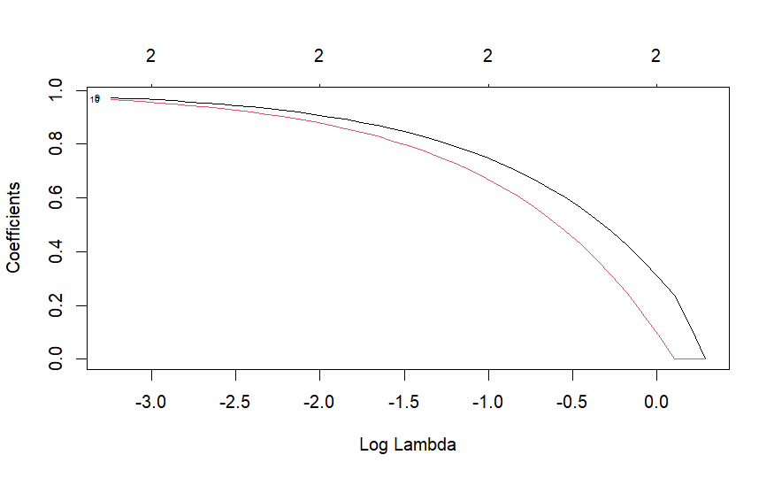

```r
#Para saber el lambda modelo 30
lasso.model$lambda[30]
```

```
[1] 0.09008879
```

```r
log(lasso.model$lambda[30])
```

```
[1] -2.406959
```

```r
print(coef30)
```

```
                  (Intercept)                           age               positionForward
                   0.04668576                    0.00000000                    0.00000000
           positionGoalkeeper            positionMidfielder        minutes_played_overall
                   0.00000000                    0.00000000                    0.00000000
          minutes_played_home           appearances_overall              appearances_home
                   0.00000000                    0.00000000                    0.00000000
                   goals_home                    goals_away               assists_overall
                   0.93814647                    0.91887211                    0.00000000
                 assists_home                 penalty_goals                penalty_misses
                   0.00000000                    0.00000000                    0.00000000
         clean_sheets_overall             clean_sheets_home              conceded_overall
                   0.00000000                    0.00000000                    0.00000000
                conceded_home          yellow_cards_overall             red_cards_overall
                   0.00000000                    0.00000000                    0.00000000
goals_involved_per_90_overall        assists_per_90_overall          goals_per_90_overall
                   0.00000000                    0.00000000                    0.00000000
            goals_per_90_home             goals_per_90_away          min_per_goal_overall
                   0.00000000                    0.00000000                    0.00000000
      conceded_per_90_overall      min_per_conceded_overall                 min_per_match
                   0.00000000                    0.00000000                    0.00000000
         min_per_card_overall          cards_per_90_overall
                   0.00000000                    0.00000000
```

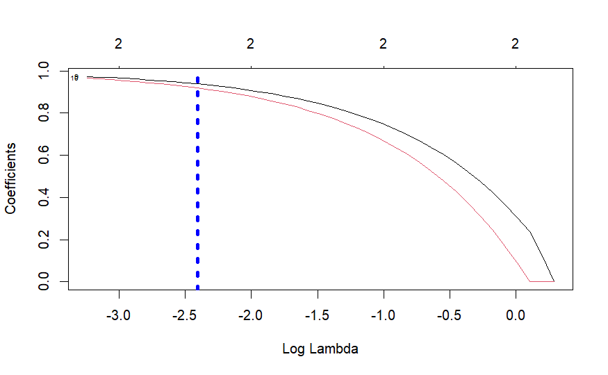

```r
lasso.model$lambda[15]
```

```
[1] 0.36369
```

```r
log(lasso.model$lambda[15])
```

```
[1] -1.011453
```

```r
coef(lasso.model)[,15]
```

```
                  (Intercept)                           age               positionForward
                    0.1884814                     0.0000000                     0.0000000
           positionGoalkeeper            positionMidfielder        minutes_played_overall
                    0.0000000                     0.0000000                     0.0000000
          minutes_played_home           appearances_overall              appearances_home
                    0.0000000                     0.0000000                     0.0000000
                   goals_home                    goals_away               assists_overall
                    0.7502462                     0.6725195                     0.0000000
                 assists_home                 penalty_goals                penalty_misses
                    0.0000000                     0.0000000                     0.0000000
         clean_sheets_overall             clean_sheets_home              conceded_overall
                    0.0000000                     0.0000000                     0.0000000
                conceded_home          yellow_cards_overall             red_cards_overall
                    0.0000000                     0.0000000                     0.0000000
goals_involved_per_90_overall        assists_per_90_overall          goals_per_90_overall
                    0.0000000                     0.0000000                     0.0000000
            goals_per_90_home             goals_per_90_away          min_per_goal_overall
                    0.0000000                     0.0000000                     0.0000000
      conceded_per_90_overall      min_per_conceded_overall                 min_per_match
                    0.0000000                     0.0000000                     0.0000000
         min_per_card_overall          cards_per_90_overall
                    0.0000000                     0.0000000
```

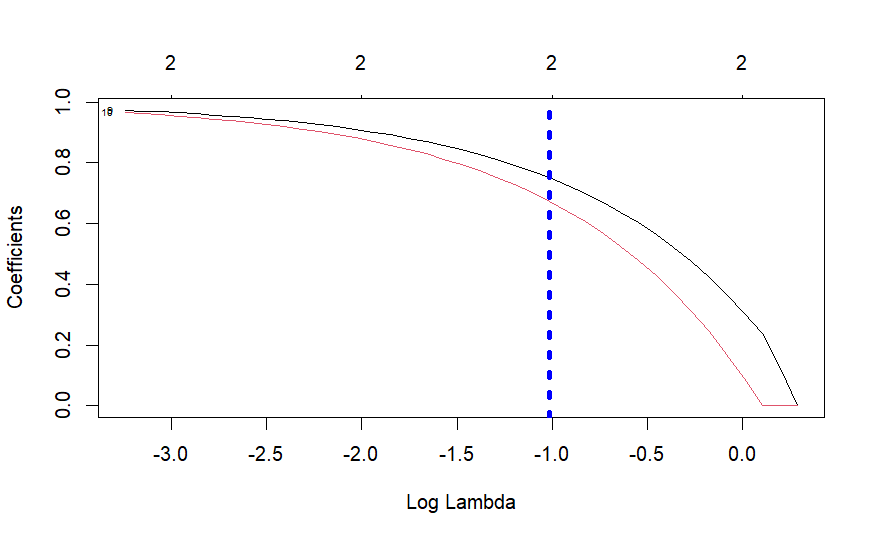

```r
print(pred)
```

```
            s1
1   0.03875934
4   0.03875934
18  0.03875934
20  0.03875934
21  0.03875934
25  0.03875934
35  0.03875934
40  0.03875934
43  5.68264230
54  0.03875934
60  0.03875934
66  2.85269986
70  0.03875934
72  0.98740745
```

[output cut: 113 more lines]

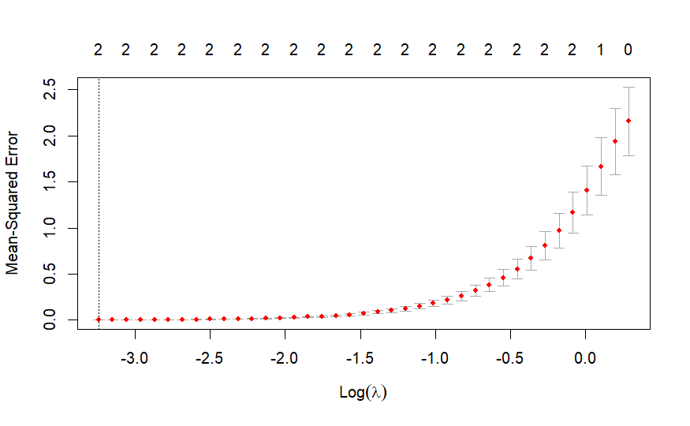

```r
mejor.lambda
```

```
[1] 0.03899729
```

```r
log(mejor.lambda)
```

```
[1] -3.244263
```

```r
#hacer predicción conmejor lambda
coef(lasso.model)[,which(lasso.model$lambda==mejor.lambda)]
```

```
                  (Intercept)                           age               positionForward
                    0.0202051                     0.0000000                     0.0000000
           positionGoalkeeper            positionMidfielder        minutes_played_overall
                    0.0000000                     0.0000000                     0.0000000
          minutes_played_home           appearances_overall              appearances_home
                    0.0000000                     0.0000000                     0.0000000
                   goals_home                    goals_away               assists_overall
                    0.9732450                     0.9648681                     0.0000000
                 assists_home                 penalty_goals                penalty_misses
                    0.0000000                     0.0000000                     0.0000000
         clean_sheets_overall             clean_sheets_home              conceded_overall
                    0.0000000                     0.0000000                     0.0000000
                conceded_home          yellow_cards_overall             red_cards_overall
                    0.0000000                     0.0000000                     0.0000000
goals_involved_per_90_overall        assists_per_90_overall          goals_per_90_overall
                    0.0000000                     0.0000000                     0.0000000
            goals_per_90_home             goals_per_90_away          min_per_goal_overall
                    0.0000000                     0.0000000                     0.0000000
      conceded_per_90_overall      min_per_conceded_overall                 min_per_match
                    0.0000000                     0.0000000                     0.0000000
         min_per_card_overall          cards_per_90_overall
                    0.0000000                     0.0000000
```

```r
pred
```

```
           s1
1   0.0202051
4   0.0202051
18  0.0202051
20  0.0202051
21  0.0202051
25  0.0202051
35  0.0202051
40  0.0202051
43  5.8345443
54  0.0202051
60  0.0202051
66  2.9231863
70  0.0202051
72  0.9934501
```

[output cut: 113 more lines]

Ahora haremos una regresión múltiple no lineal`

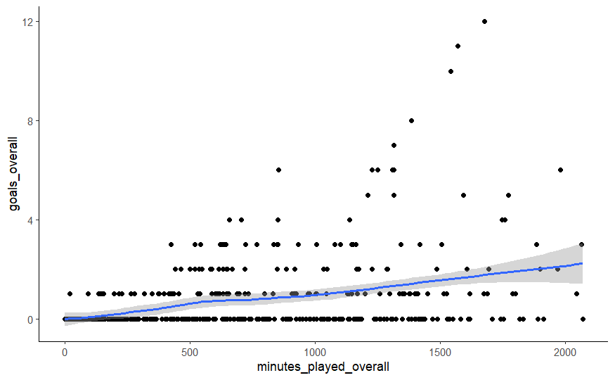

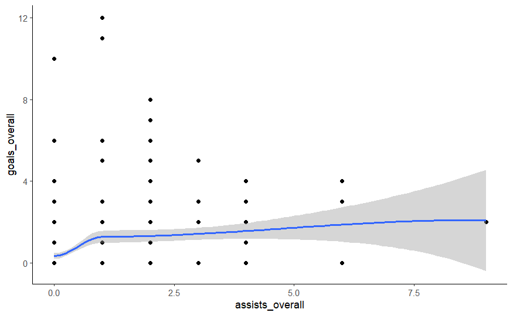

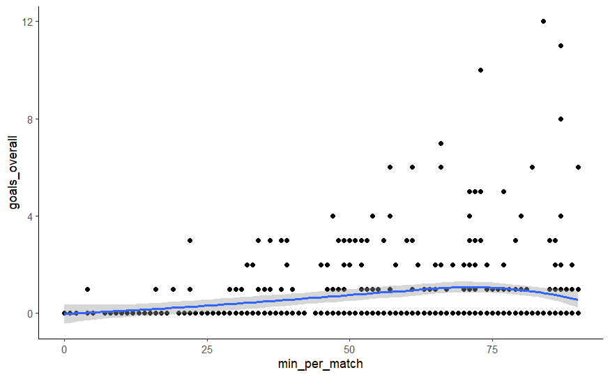

```r
ggplot(train.datos, aes( minutes_played_overall ,goals_overall))+ geom_point () + stat_smooth()
ggplot(train.datos, aes( assists_overall ,goals_overall))+ geom_point () + stat_smooth()

ggplot(train.datos, aes( min_per_match ,goals_overall))+ geom_point () + stat_smooth()
```

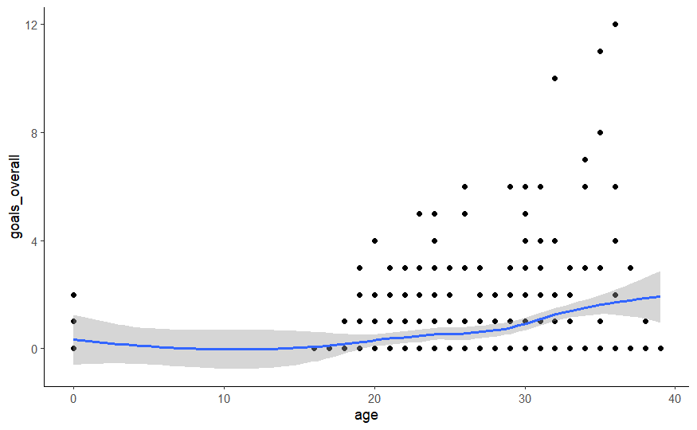

```r
ggplot(train.datos, aes( age ,goals_overall))+ geom_point () + stat_smooth()
```

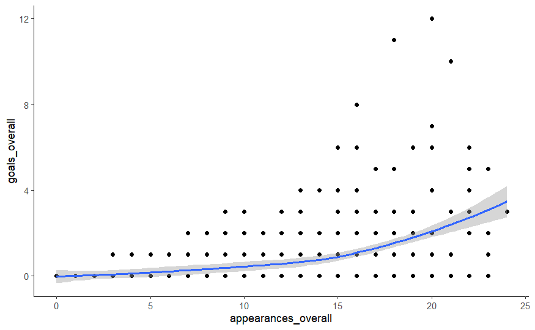

```r
ggplot(train.datos, aes( appearances_overall ,goals_overall))+ geom_point () + stat_smooth()
```

```r
#Genera el modelo de regresion con variables categóricas en R
modeloA <-lm(goalls_overall ~ appearances_overall, data =train.datos)
```

```
Error in eval(predvars, data, env) : object 'goalls_overall' not found
```

```r
#Coeficientes del Modelo
summary(modelo1)$coef
```

[output not shown]

```r
prediccionesA
```

```
          1           4          18          20          21          25          35          40
-0.11628133  0.07841881 -0.11628133  0.46781908  1.53866982  1.92807008  0.56516914  1.05191948
         43          54          60          66          70          72          79          82
 0.95456941 -0.11628133 -0.11628133  1.53866982 -0.11628133  1.34396968  1.24661961  1.53866982
         85          88          95         105         110         114         121         123
-0.21363139  1.14926955  1.34396968  1.83072002  1.53866982  1.14926955  1.34396968 -0.01893126
        133         137         139         144         152         154         161         163
 1.53866982  0.46781908  1.83072002  1.83072002 -0.11628133  1.14926955 -0.01893126  0.75986928
        169         172         174         178         184         193         198         208
 0.95456941 -0.11628133  1.53866982 -0.11628133 -0.21363139 -0.31098146  0.17576888  0.85721935
        210         224         226         227         229         233         241         244
 0.75986928  1.34396968  1.53866982  1.53866982  1.53866982  1.73336995  0.37046901  0.66251921
        248         249         251         257         260         262         265         274
 1.14926955  1.34396968  1.05191948  1.05191948  1.05191948  0.85721935  1.24661961  1.92807008
        278         291         298         301         307         312         319         321
-0.31098146 -0.01893126  1.34396968 -0.21363139  0.66251921  1.05191948  0.95456941  0.17576888
        348         350         368         373         377         378         381         382
 1.14926955  1.14926955 -0.31098146  1.24661961  1.14926955  0.95456941  0.75986928  0.27311894
        386         393         397         398         401         416         423         425
 0.75986928 -0.31098146  1.14926955  0.56516914  0.27311894  1.24661961  1.34396968 -0.21363139
        427         436         441         446         452         460         466         467
-0.21363139  0.07841881 -0.31098146  0.85721935  1.53866982  0.27311894  1.83072002  1.63601988
        470         475         481         496         501         511         517         518
 1.83072002  1.24661961  1.44131975  1.05191948  0.17576888  0.27311894  1.63601988  1.14926955
        520         523         524         525         527         532         554         557
-0.31098146  1.05191948  1.14926955  1.14926955  1.44131975  1.44131975 -0.21363139  0.07841881
        558         563         564         565         567         580         583         586
 0.27311894  1.14926955  0.75986928  0.07841881  1.24661961  0.56516914  0.56516914 -0.31098146
        587         593         597         603         605         607         608         610
 0.17576888  1.14926955 -0.01893126 -0.31098146  0.95456941 -0.31098146  1.63601988  0.17576888
        612         613         614         624         626         627         628
 0.56516914  1.44131975  0.85721935  1.63601988 -0.21363139  1.05191948  0.56516914
```

| RMSE | R2 |
| --- | --- |
| 1.700501 | 0.1362296 |

[figure not shown]

```r
#Realiza las predicciones
modeloB <- lm(goals_overall  ~ poly(appearances_overall,5),data = train.datos)
summary(modeloB)$coef
```

```
                                Estimate Std. Error    t value     Pr(>|t|)
(Intercept)                    0.6686275 0.05775618 11.5767252 1.203170e-27
poly(appearances_overall, 5)1 14.4760539 1.30431823 11.0985598 9.343269e-26
poly(appearances_overall, 5)2  5.9599761 1.30431823  4.5694187 6.157981e-06
poly(appearances_overall, 5)3  1.9159294 1.30431823  1.4689126 1.424804e-01
poly(appearances_overall, 5)4 -0.4248211 1.30431823 -0.3257036 7.447838e-01
poly(appearances_overall, 5)5 -2.1543716 1.30431823 -1.6517224 9.921402e-02
```

```r
prediccionesB <- modeloB %>% predict(test.datos)
prediccionesB
```

```
            1             4            18            20            21            25            35            40            43
-0.0611726855  0.0912944094 -0.0611726855  0.3893576037  1.8984400653  2.7622447485  0.4212341793  0.6877298749  0.5818985752
           54            60            66            70            72            79            82            85            88
-0.0611726855 -0.0611726855  1.8984400653 -0.0611726855  1.2904768394  1.0404516305  1.8984400653 -0.0561244723  0.8391841634
           95           105           110           114           121           123           133           137           139
 1.2904768394  2.7017136027  1.8984400653  0.8391841634  1.2904768394 -0.0001333118  1.8984400653  0.3893576037  2.7017136027
          144           152           154           161           163           169           172           174           178
 2.7017136027 -0.0611726855  0.8391841634 -0.0001333118  0.4720265820  0.5818985752 -0.0611726855  1.8984400653 -0.0611726855
          184           193           198           208           210           224           226           227           229
-0.0561244723  0.0626044321  0.1879866813  0.5135728697  0.4720265820  1.2904768394  1.8984400653  1.8984400653  1.8984400653
          233           241           244           248           249           251           257           260           262
 2.4996177537  0.3416363695  0.4452431763  0.8391841634  1.2904768394  0.6877298749  0.6877298749  0.6877298749  0.5135728697
          265           274           278           291           298           301           307           312           319
 1.0404516305  2.7622447485  0.0626044321 -0.0001333118  1.2904768394 -0.0561244723  0.4452431763  0.6877298749  0.5818985752
          321           348           350           368           373           377           378           381           382
 0.1879866813  0.8391841634  0.8391841634  0.0626044321  1.0404516305  0.8391841634  0.5818985752  0.4720265820  0.2740767276
          386           393           397           398           401           416           423           425           427
 0.4720265820  0.0626044321  0.8391841634  0.4212341793  0.2740767276  1.0404516305  1.2904768394 -0.0561244723 -0.0561244723
          436           441           446           452           460           466           467           470           475
 0.0912944094  0.0626044321  0.5135728697  1.8984400653  0.2740767276  2.7017136027  2.2161732718  2.7017136027  1.0404516305
          481           496           501           511           517           518           520           523           524
 1.5816403037  0.6877298749  0.1879866813  0.2740767276  2.2161732718  0.8391841634  0.0626044321  0.6877298749  0.8391841634
          525           527           532           554           557           558           563           564           565
 0.8391841634  1.5816403037  1.5816403037 -0.0561244723  0.0912944094  0.2740767276  0.8391841634  0.4720265820  0.0912944094
          567           580           583           586           587           593           597           603           605
 1.0404516305  0.4212341793  0.4212341793  0.0626044321  0.1879866813  0.8391841634 -0.0001333118  0.0626044321  0.5818985752
          607           608           610           612           613           614           624           626           627
 0.0626044321  2.2161732718  0.1879866813  0.4212341793  1.5816403037  0.5135728697  2.2161732718 -0.0561244723  0.6877298749
          628
 0.4212341793
```

| RMSE | R2 |
| --- | --- |
| 1.731278 | 0.1134635 |

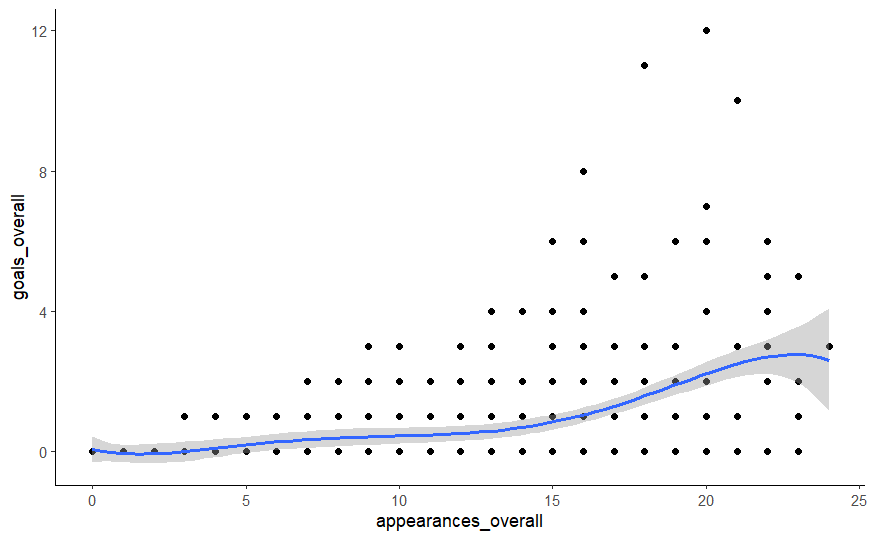